# Home Credit Default Risk: Business Impact

- Show All Code
- Hide All Code
- View Source

Author

Bradyn Jackson

Published

October 23, 2026

```r
library(tidyverse)
library(scales)
library(knitr)

# Loads tidymodels, the shared constants and the business-impact helpers
# (section 11).
source("modeling_functions.R")

theme_set(theme_minimal(base_size = 12))

model_colour     <- "#4C6EF5"
benchmark_colour <- "#868E96"
```

# Introduction

The modeling notebook chose a final model on AUC. This notebook turns that model into lending outcomes: how many applicants could be approved, and how many of them would default, compared with a simpler way of ranking applicants.

- **The model** is the final configuration from the modeling notebook: tuned XGBoost, no `CODE_GENDER`.
- **The benchmark** is `EXT_SOURCE_MEAN`, the average of the external credit scores (higher = safer). It stands in for underwriting on a bureau score alone.

Both are judged on **out-of-fold predictions**. Every training applicant is scored by a model that never saw their outcome, so each prediction is an honest estimate of how the model would score a new applicant.

# Final model setup

The final configuration is rebuilt from the modeling notebook’s cached tuning, re-scoring and tree-count results. Nothing below refits: every line printed should say the result was loaded from the cache.

```r
prepared <- load_prepared()
train    <- prepared$train
test     <- prepared$test

cv_metrics <- metric_set(roc_auc, accuracy)

compare_data  <- stratified_sample(train, prop = COMPARE_PROP)
compare_folds <- make_cv_folds(compare_data)
tune_data     <- stratified_sample(train, n = TUNE_N)
tune_folds    <- make_cv_folds(tune_data)
```

```r
xgb_tune_wf <- workflow(build_recipe(tune_data), xgb_tune_spec())
xgb_grid    <- random_tune_grid(xgb_tune_wf, tune_data, size = 20)
xgb_tuning  <- tune_grid_cached("xgb_tuning", xgb_tune_wf, tune_folds,
                                xgb_grid, cv_metrics)
```

```
Loaded cached result for xgb_tuning from data/cv_xgb_tuning.rds (fit 2026-10-11 10:19, took 31.1 s)
```

```r
xgb_rescored <- rescore_top(xgb_tuning, xgb_tune_wf, compare_folds, cv_metrics, n = 3)
```

```
Loaded cached result for xgb_tuned_pre0_mod20_post0 from data/cv_xgb_tuned_pre0_mod20_post0.rds (fit 2026-10-11 10:19, took 18.0 s)
Loaded cached result for xgb_tuned_pre0_mod17_post0 from data/cv_xgb_tuned_pre0_mod17_post0.rds (fit 2026-10-11 10:20, took 36.0 s)
Loaded cached result for xgb_tuned_pre0_mod14_post0 from data/cv_xgb_tuned_pre0_mod14_post0.rds (fit 2026-10-11 10:21, took 28.0 s)
```

```r
best_config  <- map(xgb_rescored, \(f) collect_metrics(f$result)) |>
  list_rbind(names_to = ".config") |>
  filter(.metric == "roc_auc") |>
  slice_max(mean, n = 1) |>
  pull(.config)
best_params <- show_best(xgb_tuning$result, metric = "roc_auc", n = 3) |>
  filter(.config == best_config) |>
  select(mtry:sample_size)

trees_sweep <- sweep_trees(extract_preprocessor(xgb_tune_wf), best_params,
                           trees = c(500, 1000, 1500, 2000),
                           folds = compare_folds, metrics = cv_metrics)
```

```
Loaded cached result for xgb_trees_500 from data/cv_xgb_trees_500.rds (fit 2026-10-11 11:17, took 27.8 s)
Loaded cached result for xgb_trees_1000 from data/cv_xgb_trees_1000.rds (fit 2026-10-11 11:18, took 48.9 s)
Loaded cached result for xgb_trees_1500 from data/cv_xgb_trees_1500.rds (fit 2026-10-11 11:19, took 70.2 s)
Loaded cached result for xgb_trees_2000 from data/cv_xgb_trees_2000.rds (fit 2026-10-11 11:21, took 91.2 s)
```

```r
best_trees  <- pick_trees(trees_sweep)

final_exclude <- "CODE_GENDER"
final_wf <- finalize_workflow(
  workflow(build_recipe(train, exclude = final_exclude),
           xgb_tune_spec(trees = best_trees)),
  best_params)

final     <- fit_final_cached("xgb_tuned_final_nogender", final_wf, train)
```

```
Loaded cached result for xgb_tuned_final_nogender from models/xgb_tuned_final_nogender.rds (fit 2026-10-11 11:35, took 53.3 s)
```

```r
final_fit <- final$result
```

The rebuilt configuration should match the saved final model exactly:

```r
saved_args <- map(extract_spec_parsnip(final_fit)$args, rlang::eval_tidy)

config_check <- tibble(
  parameter = c(names(best_params), "trees"),
  rebuilt   = c(map_dbl(best_params, as.numeric), best_trees),
  saved     = map_dbl(parameter, \(p) as.numeric(saved_args[[p]]))
) |>
  mutate(match = rebuilt == saved)

stopifnot(all(config_check$match))
config_check |> kable(digits = 6)
```

| parameter | rebuilt | saved | match |
| --- | --- | --- | --- |
| mtry | 132.000000 | 132.000000 | TRUE |
| min_n | 38.000000 | 38.000000 | TRUE |
| tree_depth | 12.000000 | 12.000000 | TRUE |
| learn_rate | 0.011034 | 0.011034 | TRUE |
| loss_reduction | 0.000002 | 0.000002 | TRUE |
| sample_size | 0.805303 | 0.805303 | TRUE |
| trees | 500.000000 | 500.000000 | TRUE |

# Out-of-fold predictions

All 307,511 training rows are split into 3 stratified folds with `pool = 0.05`, as in the modeling notebook. Each fold is predicted by the final configuration fit on the other two, so every applicant gets exactly one prediction from a model that did not train on them. Only the predictions and per-fold metrics are cached, to `data/cv_xgb_final_oof.rds`.

```r
full_folds <- make_cv_folds(train)

oof <- oof_predictions_cached("xgb_final_oof", final_wf, full_folds, cv_metrics)
```

```
Loaded cached result for xgb_final_oof from data/cv_xgb_final_oof.rds (fit 2026-10-14 18:47, took 149.4 s)
```

The raw loan amount is read from the original CSV. The prepared data caps `AMT_CREDIT` at the 99th percentile (1,854,000), which would understate the credit held by the largest defaulted loans.

```r
prep_env  <- new.env()
source("data_preparation.R", local = prep_env)
raw_train <- prep_env$read_application("data/application_train.csv")
stopifnot(identical(raw_train$SK_ID_CURR, train$SK_ID_CURR))

scored <- oof$result$predictions |>
  arrange(.row) |>
  transmute(fold         = id,
            SK_ID_CURR   = train$SK_ID_CURR[.row],
            TARGET,
            default      = TARGET == "1",
            model_risk   = .pred_1,
            ext_source   = train$EXT_SOURCE_MEAN[.row],
            credit       = raw_train$AMT_CREDIT[.row])

n_applicants <- nrow(scored)
per_100k     <- 1e5 / n_applicants
```

Each fold should cover a third of the rows at the full default rate, every row should be predicted once, and the mean predicted default should match the actual rate in every fold:

```r
stopifnot(n_applicants == nrow(train),
          n_distinct(scored$SK_ID_CURR) == nrow(train),
          identical(scored$TARGET, train$TARGET))

oof_auc <- oof$result$per_fold |> filter(.metric == "roc_auc") |> select(fold = id, auc = .estimate)

scored |>
  group_by(fold) |>
  summarise(rows                   = n(),
            default_rate           = mean(default),
            mean_predicted_default = mean(model_risk),
            .groups = "drop") |>
  left_join(oof_auc, by = "fold") |>
  mutate(across(c(default_rate, mean_predicted_default), \(x) percent(x, accuracy = 0.01))) |>
  kable(digits = 4, format.args = list(big.mark = ","))
```

| fold | rows | default_rate | mean_predicted_default | auc |
| --- | --- | --- | --- | --- |
| Fold1 | 102,504 | 8.07% | 7.98% | 0.7591 |
| Fold2 | 102,504 | 8.07% | 8.03% | 0.7624 |
| Fold3 | 102,503 | 8.07% | 8.08% | 0.7650 |

Both scores ranked against the same outcomes, on all rows:

```r
score_auc <- tibble(
  score = c("Model (out-of-fold)", "Benchmark (EXT_SOURCE_MEAN)"),
  auc   = c(roc_auc_vec(scored$TARGET, scored$model_risk),
            roc_auc_vec(scored$TARGET, -scored$ext_source))
)
score_auc |> kable(digits = 4)
```

| score | auc |
| --- | --- |
| Model (out-of-fold) | 0.7621 |
| Benchmark (EXT_SOURCE_MEAN) | 0.7165 |

The out-of-fold AUC of 0.762 is above the 0.748 measured on the 20% comparison folds and close to the Kaggle private score (0.758): each fold model here trains on 205,000 rows rather than 41,000. The benchmark’s 0.716 is the bar the model has to clear to be worth more than the external scores alone.

11,985 applicants share an `EXT_SOURCE_MEAN` value with someone else, including 172 with no external score at all, who all carry the imputed median. Ties are approved in row order.

# Approval tradeoff

Both scores rank every applicant from lowest to highest risk, and the lowest-risk applicants are approved first. At each approval rate from 50% to 100%, the default rate among those approved:

```r
model_path     <- approval_path(scored$model_risk, scored$default, scored$credit)
benchmark_path <- approval_path(-scored$ext_source, scored$default, scored$credit)

approval_rates <- seq(0.50, 1.00, by = 0.01)
curve_rows     <- round(approval_rates * n_applicants)

approval_curve <- bind_rows(
  Model     = model_path[curve_rows, ],
  Benchmark = benchmark_path[curve_rows, ],
  .id = "score") |>
  mutate(approval_rate = rep(approval_rates, 2),
         score         = factor(score, levels = c("Model", "Benchmark")))
```

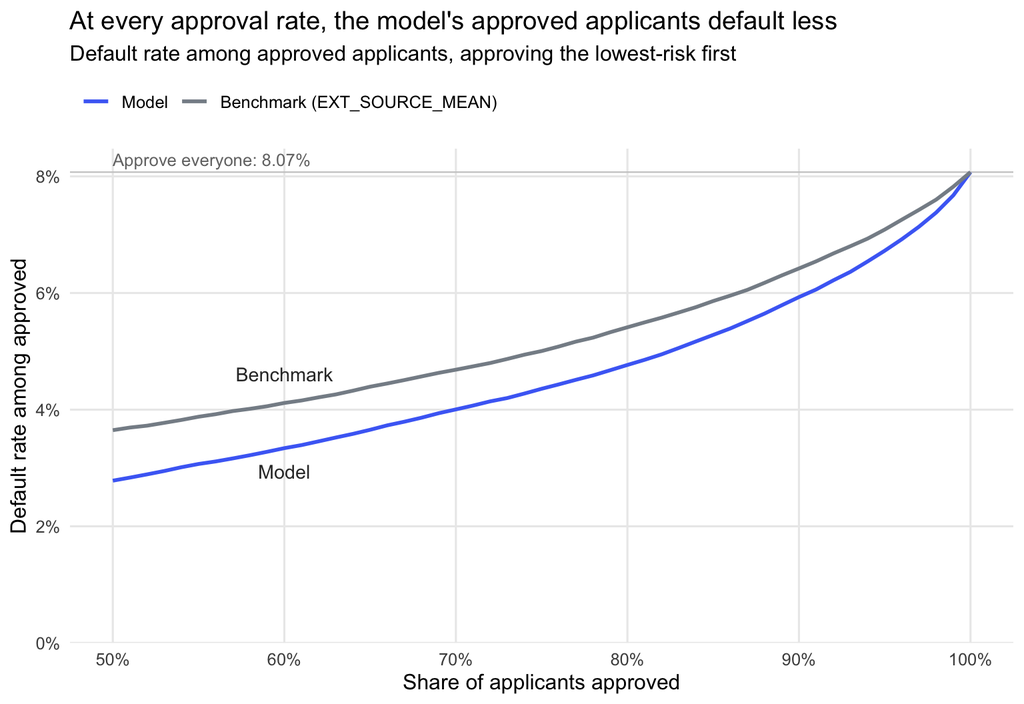

```r
# Direct labels at 60%: the model's below its line, the benchmark's above.
curve_labels <- approval_curve |>
  filter(approval_rate == 0.60) |>
  mutate(label = as.character(score),
         default_rate = default_rate + if_else(score == "Model", -0.004, 0.005))

ggplot(approval_curve, aes(approval_rate, default_rate, colour = score)) +
  geom_hline(yintercept = mean(scored$default), colour = "grey80", linewidth = 0.4) +
  geom_line(linewidth = 1) +
  geom_text(data = curve_labels, aes(label = label),
            hjust = 0.5, size = 3.8, colour = "grey20", show.legend = FALSE) +
  annotate("text", x = 0.5, y = mean(scored$default), vjust = -0.5, hjust = 0,
           size = 3.4, colour = "grey45",
           label = paste("Approve everyone:", percent(mean(scored$default), accuracy = 0.01))) +
  scale_colour_manual(values = c(Model = model_colour, Benchmark = benchmark_colour),
                      labels = c("Model", "Benchmark (EXT_SOURCE_MEAN)")) +
  scale_x_continuous(labels = percent_format(accuracy = 1), breaks = seq(0.5, 1, 0.1)) +
  scale_y_continuous(labels = percent_format(accuracy = 1), limits = c(0, NA),
                     expand = expansion(mult = c(0, 0.05))) +
  labs(
    title    = "At every approval rate, the model's approved applicants default less",
    subtitle = "Default rate among approved applicants, approving the lowest-risk first",
    x = "Share of applicants approved",
    y = "Default rate among approved",
    colour = NULL
  ) +
  theme(legend.position  = "top",
        legend.justification = "left",
        panel.grid.minor = element_blank())
```

```r
approval_curve |>
  filter(approval_rate %in% seq(0.5, 1, by = 0.1)) |>
  select(score, approval_rate, default_rate) |>
  pivot_wider(names_from = score, values_from = default_rate) |>
  mutate(difference = Benchmark - Model,
         across(everything(), \(x) percent(x, accuracy = 0.01))) |>
  rename(model_default_rate = Model, benchmark_default_rate = Benchmark,
         benchmark_minus_model = difference) |>
  kable()
```

| approval_rate | model_default_rate | benchmark_default_rate | benchmark_minus_model |
| --- | --- | --- | --- |
| 50.00% | 2.78% | 3.65% | 0.87% |
| 60.00% | 3.34% | 4.11% | 0.78% |
| 70.00% | 4.00% | 4.69% | 0.68% |
| 80.00% | 4.77% | 5.41% | 0.65% |
| 90.00% | 5.93% | 6.42% | 0.49% |
| 100.00% | 8.07% | 8.07% | 0.00% |

At 100% everyone is approved, so both curves meet at the overall default rate. Below that, the gap is how much better the model separates risky applicants from safe ones.

# Same risk, more approvals

A lender typically sets a risk appetite, a maximum default rate among approved applicants, and approves as many applicants as it can within it. For each target, each score approves the largest group of lowest-risk applicants whose default rate stays at or under the target. The path is read one applicant at a time, not in 1-point steps.

```r
targets <- c(0.04, 0.05, 0.06)

at_targets <- map(targets, \(t) {
  m <- at_target_rate(model_path, t)
  b <- at_target_rate(benchmark_path, t)
  same_size <- model_path[b$approved, ]   # the model at the benchmark's approval count
  tibble(
    target               = t,
    model_approval       = m$approval_rate,
    benchmark_approval   = b$approval_rate,
    model_cutoff         = sort(scored$model_risk)[m$approved],
    extra_approvals      = (m$approved - b$approved) * per_100k,
    extra_repay          = ((m$approved - m$defaults) - (b$approved - b$defaults)) * per_100k,
    extra_default        = (m$defaults - b$defaults) * per_100k,
    defaults_avoided     = (b$defaults - same_size$defaults) * per_100k,
    credit_avoided       = (b$defaulted_credit - same_size$defaulted_credit) * per_100k
  )
}) |>
  list_rbind()
```

**More approvals at the same default rate**, per 100,000 applicants:

```r
at_targets |>
  transmute(target_default_rate = percent(target, accuracy = 1),
            model_approval_rate     = percent(model_approval, accuracy = 0.1),
            benchmark_approval_rate = percent(benchmark_approval, accuracy = 0.1),
            extra_approvals = comma(extra_approvals),
            of_which_repay  = comma(extra_repay),
            of_which_default = comma(extra_default)) |>
  kable()
```

| target_default_rate | model_approval_rate | benchmark_approval_rate | extra_approvals | of_which_repay | of_which_default |
| --- | --- | --- | --- | --- | --- |
| 4% | 70.0% | 57.6% | 12,393 | 11,897 | 496 |
| 5% | 82.5% | 75.0% | 7,532 | 7,155 | 377 |
| 6% | 90.5% | 86.4% | 4,112 | 3,865 | 247 |

“Extra” is net: the model approves `extra_approvals` more applicants than the benchmark in total, and `of_which_repay` is how many more repaying applicants its approved group holds. The two groups differ in membership too, not just in size; each score approves some applicants the other declines.

**Fewer defaults at the same approval rate.** Here the model approves exactly as many applicants as the benchmark does at each target. The defaults it avoids, and the loan amount (`AMT_CREDIT`, in the data’s currency, not converted) those defaulted loans carried, per 100,000 applicants:

```r
at_targets |>
  transmute(target_default_rate = percent(target, accuracy = 1),
            approval_rate       = percent(benchmark_approval, accuracy = 0.1),
            defaults_avoided    = comma(defaults_avoided),
            credit_of_avoided_defaults = comma(credit_avoided)) |>
  kable()
```

| target_default_rate | approval_rate | defaults_avoided | credit_of_avoided_defaults |
| --- | --- | --- | --- |
| 4% | 57.6% | 462.7 | 266,540,658 |
| 5% | 75.0% | 483.2 | 269,118,367 |
| 6% | 86.4% | 472.5 | 255,790,075 |

`credit_of_avoided_defaults` is the loan principal of those defaulted loans, not the loss. The actual loss depends on how much was repaid before default and what was recovered, neither of which is in the application data.

## Fold check

The figures above pool predictions from three fold models. Repeating the 5% target within each fold separately shows whether the gain holds in every third of the data, not just in the pooled ranking:

```r
scored |>
  group_split(fold) |>
  map(\(d) {
    m <- at_target_rate(approval_path(d$model_risk, d$default, d$credit), 0.05)
    b <- at_target_rate(approval_path(-d$ext_source, d$default, d$credit), 0.05)
    tibble(fold                    = d$fold[1],
           model_approval_rate     = m$approval_rate,
           benchmark_approval_rate = b$approval_rate,
           extra_approvals_per_100k = (m$approved - b$approved) / nrow(d) * 1e5)
  }) |>
  list_rbind() |>
  mutate(across(ends_with("rate"), \(x) percent(x, accuracy = 0.1)),
         extra_approvals_per_100k = comma(extra_approvals_per_100k)) |>
  kable()
```

| fold | model_approval_rate | benchmark_approval_rate | extra_approvals_per_100k |
| --- | --- | --- | --- |
| Fold1 | 82.0% | 73.8% | 8,217 |
| Fold2 | 82.7% | 75.2% | 7,496 |
| Fold3 | 82.7% | 75.4% | 7,240 |

# Translating to Home Credit’s financials

This section uses only the Q1 2019 figures from the Business Problem Statement (BPS):

```r
q1_impairment_eur <- 430e6
q1_nii_eur        <- 889e6
loans_eur         <- 18755e6
cost_of_risk      <- 0.0229

bps_loss_reduction    <- 0.05   # BPS target: 5% fewer losses
bps_approval_gain_pts <- 1      # BPS target: +1 point approval rate

tibble(
  figure = c("Impairment losses, Q1 2019", "Net interest income, Q1 2019",
             "Loans to customers", "Cost of risk",
             "Check: impairment / loans to customers"),
  value  = c(sprintf("EUR %sM", comma(q1_impairment_eur / 1e6)),
             sprintf("EUR %sM", comma(q1_nii_eur / 1e6)),
             sprintf("EUR %sM", comma(loans_eur / 1e6)),
             percent(cost_of_risk, accuracy = 0.01),
             percent(q1_impairment_eur / loans_eur, accuracy = 0.01))
) |>
  kable()
```

| figure | value |
| --- | --- |
| Impairment losses, Q1 2019 | EUR 430M |
| Net interest income, Q1 2019 | EUR 889M |
| Loans to customers | EUR 18,755M |
| Cost of risk | 2.29% |
| Check: impairment / loans to customers | 2.29% |

The 2.29% cost of risk is one quarter’s impairment over the loan book, so it is a quarterly rate, and the basis-point changes below are on that basis.

## Relative reduction in defaults

At the 5% target, the benchmark approves 75.0% of applicants. The model approves the same number, and the reduction is the defaults it avoids as a share of the defaults among the benchmark’s approved applicants, measured by count and by defaulted `AMT_CREDIT`:

```r
bench_5 <- at_target_rate(benchmark_path, 0.05)
model_5 <- model_path[bench_5$approved, ]   # the model at the benchmark's approval count

reduction <- tibble(
  measure   = c("Default count", "Defaulted AMT_CREDIT"),
  benchmark = c(bench_5$defaults, bench_5$defaulted_credit),
  model     = c(model_5$defaults, model_5$defaulted_credit)
) |>
  mutate(avoided  = benchmark - model,
         relative_reduction = avoided / benchmark)

reduction |>
  mutate(across(c(benchmark, model, avoided), comma),
         relative_reduction = percent(relative_reduction, accuracy = 0.1)) |>
  kable(caption = sprintf("All %s training applicants; %s approved by each score",
                          comma(n_applicants), comma(bench_5$approved)))
```

All 307,511 training applicants; 230,502 approved by each score

| measure | benchmark | model | avoided | relative_reduction |
| --- | --- | --- | --- | --- |
| Default count | 11,525 | 10,039 | 1,486 | 12.9% |
| Defaulted AMT_CREDIT | 6,991,034,908 | 6,163,466,328 | 827,568,580 | 11.8% |

```r
count_reduction  <- reduction$relative_reduction[reduction$measure == "Default count"]
credit_reduction <- reduction$relative_reduction[reduction$measure == "Defaulted AMT_CREDIT"]
```

## Impairment and cost of risk

The `AMT_CREDIT`-based reduction is applied to impairment losses (annualised as four times Q1) and to the cost of risk. Impairment is measured in money, so the share of defaulted credit avoided is the closer match to it than the share of defaults:

```r
annual_impairment <- 4 * q1_impairment_eur

impact <- function(r) {
  tibble(loss_reduction         = r,
         annual_saving_eur      = annual_impairment * r,
         new_cost_of_risk       = cost_of_risk * (1 - r),
         cost_of_risk_change_bp = -cost_of_risk * r * 1e4)
}

impact(credit_reduction) |>
  transmute(loss_reduction         = percent(loss_reduction, accuracy = 0.1),
            annual_impairment      = sprintf("EUR %sM", comma(annual_impairment / 1e6)),
            annual_saving          = sprintf("EUR %sM", comma(annual_saving_eur / 1e6)),
            cost_of_risk           = percent(cost_of_risk, accuracy = 0.01),
            new_cost_of_risk       = percent(new_cost_of_risk, accuracy = 0.01),
            change_bp              = number(cost_of_risk_change_bp, accuracy = 0.1)) |>
  kable()
```

| loss_reduction | annual_impairment | annual_saving | cost_of_risk | new_cost_of_risk | change_bp |
| --- | --- | --- | --- | --- | --- |
| 11.8% | EUR 1,720M | EUR 204M | 2.29% | 2.02% | -27.1 |

Note: applying the count-based reduction (12.9%) instead would give an annual saving of EUR 222M and a cost of risk of 1.99% (-29.5 bp).

## Scenarios

The conservative case is the BPS target, a 5% loss reduction. The upper bound is the model’s full reduction in defaulted `AMT_CREDIT` against the benchmark. The last column is the share of the model’s edge over the benchmark that the conservative case needs.

```r
bind_rows(
  impact(bps_loss_reduction) |> mutate(scenario = "Conservative (BPS target)"),
  impact(credit_reduction)   |> mutate(scenario = "Upper bound (full reduction vs benchmark)")
) |>
  transmute(scenario,
            share_of_model_edge = percent(loss_reduction / credit_reduction, accuracy = 1),
            loss_reduction   = percent(loss_reduction, accuracy = 0.1),
            annual_saving    = sprintf("EUR %sM", comma(annual_saving_eur / 1e6)),
            new_cost_of_risk = percent(new_cost_of_risk, accuracy = 0.01),
            change_bp        = number(cost_of_risk_change_bp, accuracy = 0.1)) |>
  relocate(share_of_model_edge, .after = last_col()) |>
  kable()
```

| scenario | loss_reduction | annual_saving | new_cost_of_risk | change_bp | share_of_model_edge |
| --- | --- | --- | --- | --- | --- |
| Conservative (BPS target) | 5.0% | EUR 86M | 2.18% | -11.4 | 42% |
| Upper bound (full reduction vs benchmark) | 11.8% | EUR 204M | 2.02% | -27.1 | 100% |

The conservative case needs 42% of the reduction the model shows against the benchmark.

Note: on the count-based reduction, the upper bound would be EUR 222M a year, and the conservative case would need 39% of the model’s edge.

## Approval rate

```r
model_at_5 <- at_targets |> filter(target == 0.05)
approval_gain_pts <- (model_at_5$model_approval - model_at_5$benchmark_approval) * 100

tibble(
  measure = c("Model approval rate at 5% target", "Benchmark approval rate at 5% target",
              "Gain (percentage points)", "BPS target (percentage points)"),
  value   = c(percent(model_at_5$model_approval, accuracy = 0.1),
              percent(model_at_5$benchmark_approval, accuracy = 0.1),
              sprintf("+%.1f", approval_gain_pts),
              sprintf("+%.1f", bps_approval_gain_pts))
) |>
  kable()
```

| measure | value |
| --- | --- |
| Model approval rate at 5% target | 82.5% |
| Benchmark approval rate at 5% target | 75.0% |
| Gain (percentage points) | +7.5 |
| BPS target (percentage points) | +1.0 |

## Assumptions

- **Losses scale with defaulted credit.** Impairment is assumed to fall in proportion to the `AMT_CREDIT` of defaulted loans (11.8%; by count it is 12.9%). Actual losses also depend on how much was repaid before default, recoveries and timing, which the data does not hold.
- **`TARGET` means payment difficulty**, not necessarily a loss: some flagged loans recover in full.
- **Per-100,000 results scale proportionally** to Home Credit’s whole book, which assumes its applicants look like the training data.
- **The benchmark stands in for the current process.** Home Credit already uses machine learning in underwriting, so its current process is stronger than `EXT_SOURCE_MEAN` alone, and the upper bound overstates the gain.

# Personas

Two fictional applicants make the numbers concrete. Both start from the **median applicant**: the median of every numeric application field and the most common value of every categorical one, over all training applicants. Fields missing for more than half of applicants (such as `EXT_SOURCE_1` and `OWN_CAR_AGE`) are left missing, as they would be for a typical applicant. The employment length median excludes the 365,243 placeholder. The personas pass through the same `apply_prep()` as the real data, so every engineered feature is consistent with the fields changed.

```r
mode_of <- \(x) names(which.max(table(x)))

median_applicant <- raw_train |>
  select(-TARGET) |>
  mutate(DAYS_EMPLOYED = na_if(DAYS_EMPLOYED, 365243)) |>
  summarise(across(everything(), \(x)
    if (mean(is.na(x)) > 0.5) x[NA_integer_][1]
    else if (is.numeric(x)) median(x, na.rm = TRUE)
    else mode_of(x))) |>
  mutate(SK_ID_CURR = 0)
```

Each persona changes five things, all features the final model ranks highly: the external scores (`EXT_SOURCE_MEAN`, `_MIN`, `_MAX`, `_3`), age (`DAYS_BIRTH`), time employed (`EMPLOYED_AGE_RATIO`, `DAYS_EMPLOYED`), time since the phone number changed (`DAYS_LAST_PHONE_CHANGE`) and the loan relative to the goods price (`CREDIT_GOODS_RATIO`). The loan amount, income and payment stay at the median.

```r
years <- \(y) -round(y * 365.25)

personas_raw <- bind_rows(
  "Median applicant" = median_applicant,
  Jane = median_applicant |>
    mutate(SK_ID_CURR = 1,
           EXT_SOURCE_2 = 0.70, EXT_SOURCE_3 = 0.70,
           DAYS_BIRTH = years(50), DAYS_EMPLOYED = years(12),
           DAYS_LAST_PHONE_CHANGE = years(5),
           AMT_GOODS_PRICE = AMT_CREDIT),
  Marcus = median_applicant |>
    mutate(SK_ID_CURR = 2,
           EXT_SOURCE_2 = 0.25, EXT_SOURCE_3 = 0.25,
           DAYS_BIRTH = years(26), DAYS_EMPLOYED = years(1),
           DAYS_LAST_PHONE_CHANGE = years(2 / 12),
           AMT_GOODS_PRICE = round(AMT_CREDIT / 1.25)),
  .id = "persona")

personas <- prep_env$apply_prep(select(personas_raw, -persona), prepared$params)
stopifnot(setequal(names(personas), setdiff(names(train), "TARGET")))
```

Each changed value, with the share of training applicants at or below it, a check that each is a value real applicants hold:

```r
real <- raw_train |>
  transmute(ext_2   = EXT_SOURCE_2,
            ext_3   = EXT_SOURCE_3,
            age     = -DAYS_BIRTH / 365.25,
            employed = -na_if(DAYS_EMPLOYED, 365243) / 365.25,
            phone   = -DAYS_LAST_PHONE_CHANGE / 365.25,
            credit_goods = AMT_CREDIT / AMT_GOODS_PRICE)

persona_values <- personas_raw |>
  transmute(persona,
            ext_2   = EXT_SOURCE_2,
            ext_3   = EXT_SOURCE_3,
            age     = -DAYS_BIRTH / 365.25,
            employed = -DAYS_EMPLOYED / 365.25,
            phone   = -DAYS_LAST_PHONE_CHANGE / 365.25,
            credit_goods = AMT_CREDIT / AMT_GOODS_PRICE)

field_labels <- c(ext_2 = "External score 2", ext_3 = "External score 3",
                  age = "Age (years)", employed = "Years in current job",
                  phone = "Years since phone number changed",
                  credit_goods = "Loan / price of goods")

persona_values |>
  pivot_longer(-persona, names_to = "field") |>
  mutate(percentile = map2_dbl(field, value, \(f, v) mean(real[[f]] <= v, na.rm = TRUE)),
         shown = sprintf("%s (%s)", number(value, accuracy = 0.01), percent(percentile, accuracy = 1)),
         field = field_labels[field]) |>
  select(field, persona, shown) |>
  pivot_wider(names_from = persona, values_from = shown) |>
  kable(caption = "Value (share of training applicants at or below it)")
```

Value (share of training applicants at or below it)

| field | Median applicant | Jane | Marcus |
| --- | --- | --- | --- |
| External score 2 | 0.57 (50%) | 0.70 (85%) | 0.25 (12%) |
| External score 3 | 0.54 (50%) | 0.70 (81%) | 0.25 (12%) |
| Age (years) | 43.12 (50%) | 50.00 (66%) | 26.00 (5%) |
| Years in current job | 4.51 (50%) | 12.00 (85%) | 1.00 (11%) |
| Years since phone number changed | 2.07 (50%) | 5.00 (83%) | 0.17 (17%) |
| Loan / price of goods | 1.14 (59%) | 1.00 (35%) | 1.25 (86%) |

## Scores

The personas are scored by the final model fit on all training rows, while the cutoffs above come from out-of-fold predictions. The two are on the same scale if the final model’s predictions for new applicants (the test set) are spread like the out-of-fold ones:

```r
test_risk <- predict(final_fit, test, type = "prob")$.pred_1
probs     <- c(0.10, 0.25, 0.50, 0.75, 0.90)

rbind(`Out-of-fold (train)` = quantile(scored$model_risk, probs),
      `Final model (test)`  = quantile(test_risk, probs)) |>
  kable(digits = 4)
```

|  | 10% | 25% | 50% | 75% | 90% |
| --- | --- | --- | --- | --- | --- |
| Out-of-fold (train) | 0.0180 | 0.0287 | 0.0521 | 0.1012 | 0.1811 |
| Final model (test) | 0.0177 | 0.0285 | 0.0536 | 0.1051 | 0.1809 |

```r
cutoff_5 <- at_targets$model_cutoff[at_targets$target == 0.05]

persona_scores <- tibble(
  persona = personas_raw$persona,
  predicted_default = predict(final_fit, personas, type = "prob")$.pred_1
) |>
  mutate(cutoff_at_5pct_target = cutoff_5,
         decision = if_else(predicted_default <= cutoff_5, "Approve", "Decline"))

persona_scores |>
  mutate(across(c(predicted_default, cutoff_at_5pct_target), \(x) percent(x, accuracy = 0.1))) |>
  kable()
```

| persona | predicted_default | cutoff_at_5pct_target | decision |
| --- | --- | --- | --- |
| Median applicant | 13.7% | 13.1% | Decline |
| Jane | 2.0% | 13.1% | Approve |
| Marcus | 29.1% | 13.1% | Decline |

At the 5% target the model approves applicants with a predicted default probability up to 13.1%. The marginal applicant carries far more risk than the 5% average, because the approved group is mostly much safer applicants. The median applicant sits close to that line.

## Why: top 5 factors

`predcontrib = TRUE` splits each persona’s prediction into one contribution per feature, on the log-odds scale. The contributions add to the persona’s predicted log-odds of default, starting from the model’s baseline for an average applicant. `xgb_contributions()` checks that sum against the model’s own prediction before returning anything.

Several features encode the same input: age appears as `DAYS_BIRTH`, `AGE_YEARS` and `AGE_BAND`; the external scores as each score plus their mean, minimum, maximum and count; categories as one dummy per level. Their contributions are added together, so each row below is one thing about the applicant.

```r
factor_cols <- names(select(train, where(is.factor), -TARGET))

contributions <- xgb_contributions(final_fit, personas) |>
  mutate(persona = personas_raw$persona[.row])

baseline_log_odds <- contributions |>
  filter(feature == "BIAS") |>
  pull(contribution) |>
  unique()

grouped <- contributions |>
  filter(feature != "BIAS") |>
  mutate(factor = feature_group(feature, factor_cols)) |>
  group_by(persona, factor) |>
  summarise(contribution = sum(contribution), .groups = "drop")
```

The baseline is -2.44 log-odds, a 8.1% default probability.

```r
for (who in c("Jane", "Marcus")) {
  score <- persona_scores$predicted_default[persona_scores$persona == who]
  cat(sprintf("\n**%s**: predicted default %s (%s at the 5%% target)\n\n",
              who, percent(score, accuracy = 0.1),
              persona_scores$decision[persona_scores$persona == who]))
  grouped |>
    filter(persona == who) |>
    slice_max(abs(contribution), n = 5) |>
    transmute(rank   = row_number(),
              factor,
              effect = if_else(contribution > 0, "pushes risk up", "pushes risk down"),
              log_odds = contribution) |>
    kable(digits = 2) |>
    print()
  cat("\n")
}
```

**Jane**: predicted default 2.0% (Approve at the 5% target)

| rank | factor | effect | log_odds |
| --- | --- | --- | --- |
| 1 | External credit scores | pushes risk down | -1.19 |
| 2 | Loan relative to price of goods | pushes risk down | -0.12 |
| 3 | Years in current job | pushes risk down | -0.10 |
| 4 | Payment relative to loan (implied term) | pushes risk up | 0.07 |
| 5 | Time since phone number changed | pushes risk down | -0.07 |

**Marcus**: predicted default 29.1% (Decline at the 5% target)

| rank | factor | effect | log_odds |
| --- | --- | --- | --- |
| 1 | External credit scores | pushes risk up | 0.99 |
| 2 | Age | pushes risk down | -0.17 |
| 3 | Payment relative to loan (implied term) | pushes risk up | 0.14 |
| 4 | Loan relative to price of goods | pushes risk up | 0.12 |
| 5 | Price of goods financed | pushes risk up | 0.07 |

A contribution is measured against the baseline applicant, not against the median applicant the personas started from, so an unchanged feature can still appear in the list.

Marcus’s age pushes his risk *down*, although default falls with age overall in the EDA. That is what the data show once the external scores are known: among applicants with external scores as low as his, younger applicants default no more often than middle-aged ones, so the youth effect seen overall is already carried by the scores.

```r
marcus_ext <- personas$EXT_SOURCE_MEAN[personas_raw$persona == "Marcus"]

train |>
  mutate(group = if_else(EXT_SOURCE_MEAN <= 0.35, "low_ext_score", "other")) |>
  group_by(AGE_BAND) |>
  summarise(all_applicants        = mean(TARGET == "1"),
            low_ext_score_default = mean(TARGET[group == "low_ext_score"] == "1"),
            low_ext_score_rows    = sum(group == "low_ext_score"),
            .groups = "drop") |>
  mutate(across(c(all_applicants, low_ext_score_default), \(x) percent(x, accuracy = 0.1))) |>
  kable(format.args = list(big.mark = ","),
        caption = sprintf("Default rate by age band; low external score = EXT_SOURCE_MEAN at or below 0.35 (Marcus: %.2f)",
                          marcus_ext))
```

Default rate by age band; low external score = EXT_SOURCE_MEAN at or below 0.35 (Marcus: 0.25)

| AGE_BAND | all_applicants | low_ext_score_default | low_ext_score_rows |
| --- | --- | --- | --- |
| [20,25) | 12.3% | 18.7% | 5,231 |
| [25,30) | 11.1% | 21.2% | 8,981 |
| [30,35) | 10.3% | 23.6% | 7,507 |
| [35,40) | 9.0% | 23.8% | 5,944 |
| [40,45) | 7.8% | 23.1% | 4,511 |
| [45,50) | 7.4% | 21.5% | 3,495 |
| [50,55) | 6.7% | 18.7% | 3,495 |
| [55,60) | 5.5% | 16.1% | 3,406 |
| [60,65) | 5.3% | 13.2% | 2,942 |
| [65,70] | 3.7% | 8.7% | 796 |

# Limitations

- **Approved applicants only.** The training data holds only applicants Home Credit approved; those it declined, and how they would have repaid, are not in it (no reject inference). The approval rates here re-rank the applicants Home Credit already approved. They do not show what would happen to applicants it declined, who are likely riskier.
- **The benchmark is a stand-in.** `EXT_SOURCE_MEAN` represents underwriting on external scores alone. It is not Home Credit’s actual approval policy, which is not in the data, so the gains above are measured against this stand-in, not against the current process.
- **`TARGET` marks payment difficulties**, not necessarily a written-off loan, and `AMT_CREDIT` is principal, not loss.